# Project 3

Thomas

11/28/2021

# Introduction and description of database

The population of Switzerland is now of 8,670 millions in 2020 which was of 7,955 millions in 2011. The number is growing and the number of foreigner citizen is too, from which some of them get the Swiss citizenship. In this document we will explore a database about the acquisition of Swiss nationality.

This database is composed of the following:

- `Previous.citizenship`: the previous citizenship of the individual;
- `Age`: the age of the individual;
- `Genre`: the gender of the individual (either `Male` or `Female`):
- `Type.of.acquisition`: the type of acquisition with the following values:
  - `Confirmation of the Swiss nationality`: when the individual claimed to be a Swiss citizen and had to prove it to the authorities;
  - `Naturalisation by adoption`: when the individual is adopted by a Swiss citizen;
  - `Ordinary naturalisation`: which is the standard way to acquire Swiss citizenship;
  - `Reintegration`: when individual had Swiss citizenship but lost it in the past;
  - `Simplified naturalisation`: for special cases, e.g., wife or husband of a Swiss, child of a Swiss, etc.
- `Canton`: the canton where the Swiss citizenship has been acquired;
- `Year`: the year of acquisition of Swiss citizenship (from `2011` to `2020`); and,
- `Value`: the number of acquisition for all previous criteria.

# Investigating the type of acquisition

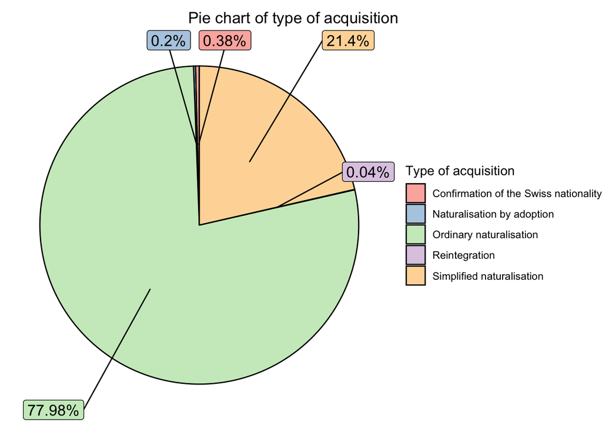

Looking at this chart, we see that there is two main type of acquisition (ordinary one and simplified one) for a total of 99.38%. As defined in the introduction, there is three type of acquisition that are really special cases (`Confirmation of the Swiss nationality`, `Naturalisation by adoption` and `Reintegration`).

We will focus on these three in the next part and then we won’t consider it anymore in order to focus on the two main types of acquisition.

## Basic exploration of three less represented types of acquisiton

Let’s take a look at the following type of acquisition : `Confirmation of the Swiss nationality`, `Naturalization by adoption` and `Reintegration`. Since each type of acquisition are quite different, we will take a look at them one by one.

### By previous citizenship

#### `Confirmation of the Swiss nationality`

First, note that there has been only `1452` confirmation between 2011 and 2020 which lead to a mean of `145.2` per year. We first plot the total number of such citizens for the 50 citizenship with the higher values and then zoom for ones with value higher than 50.

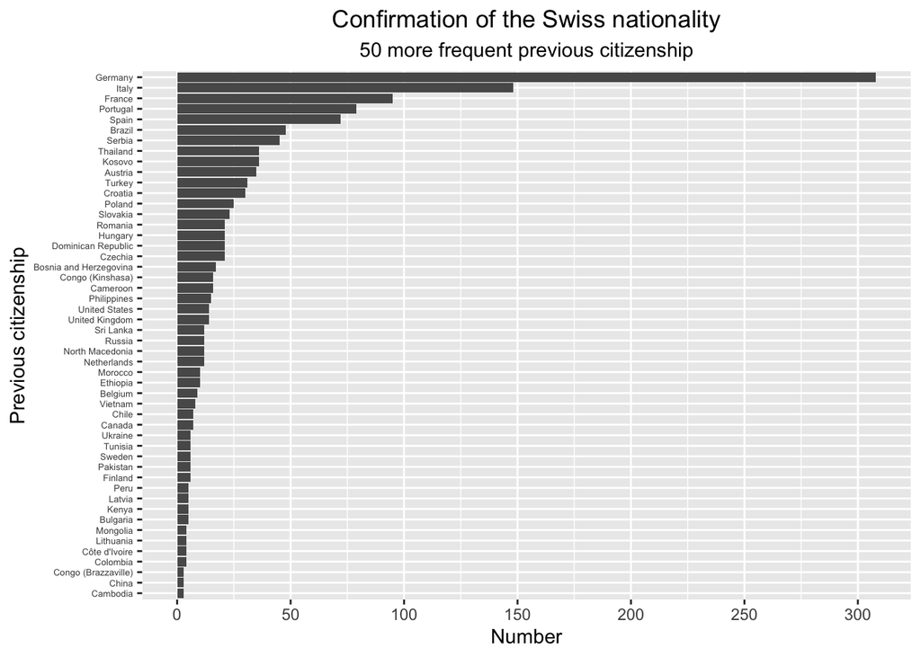

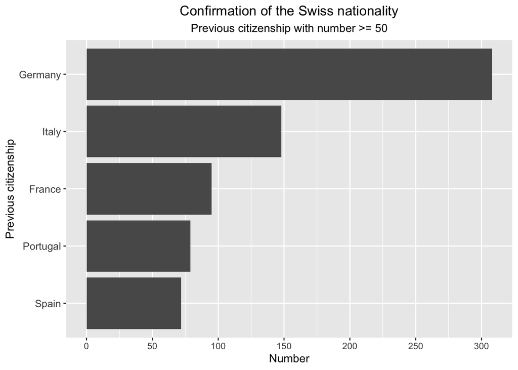

#### `Naturalization by adoption`

As before, note that there has been `776` naturalization by adoption between 2011 and 2020 which lead to a mean of `77.6` per year. We first plot the total number of such citizens for the 50 citizenship with the higher values and then zoom for ones with value higher than 25.

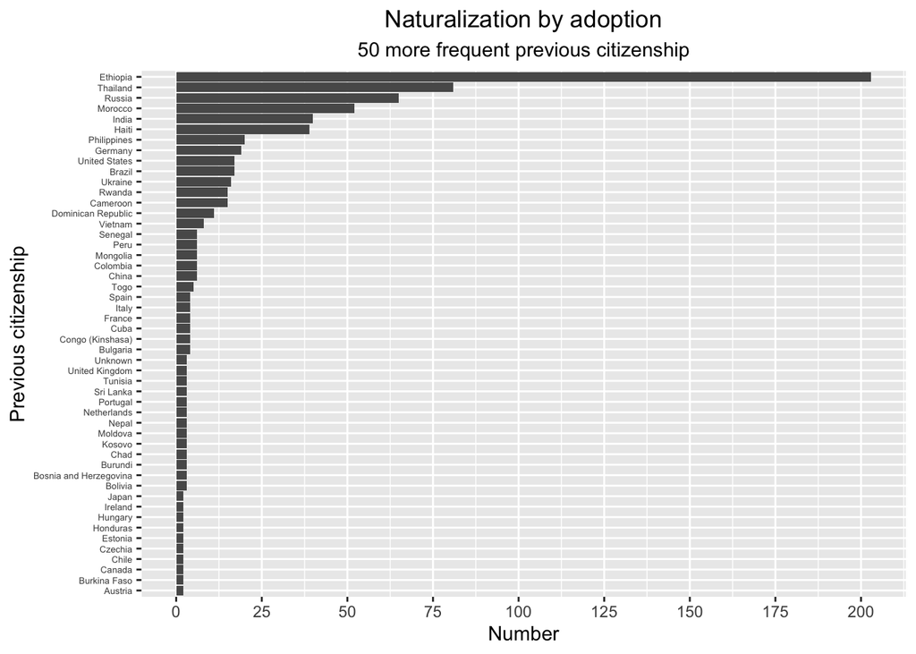

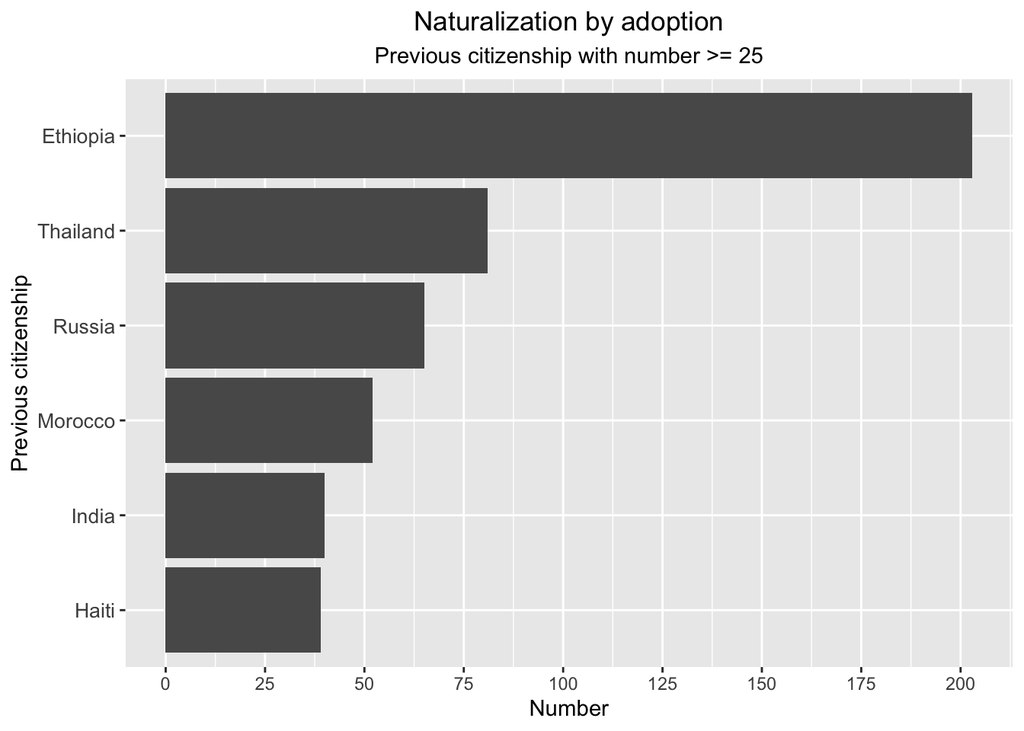

#### `Reintegration`

We can see that the top 4 is composed only by bordering countries. We see that `Stateless` appeared which means that the individual that obtained the Swiss citizenship has only Swiss nationality when he lost it.

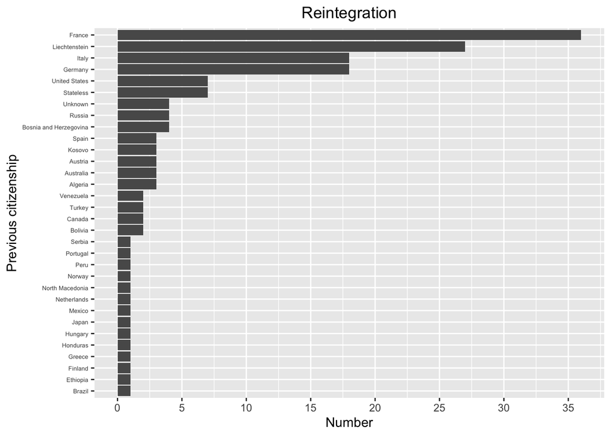

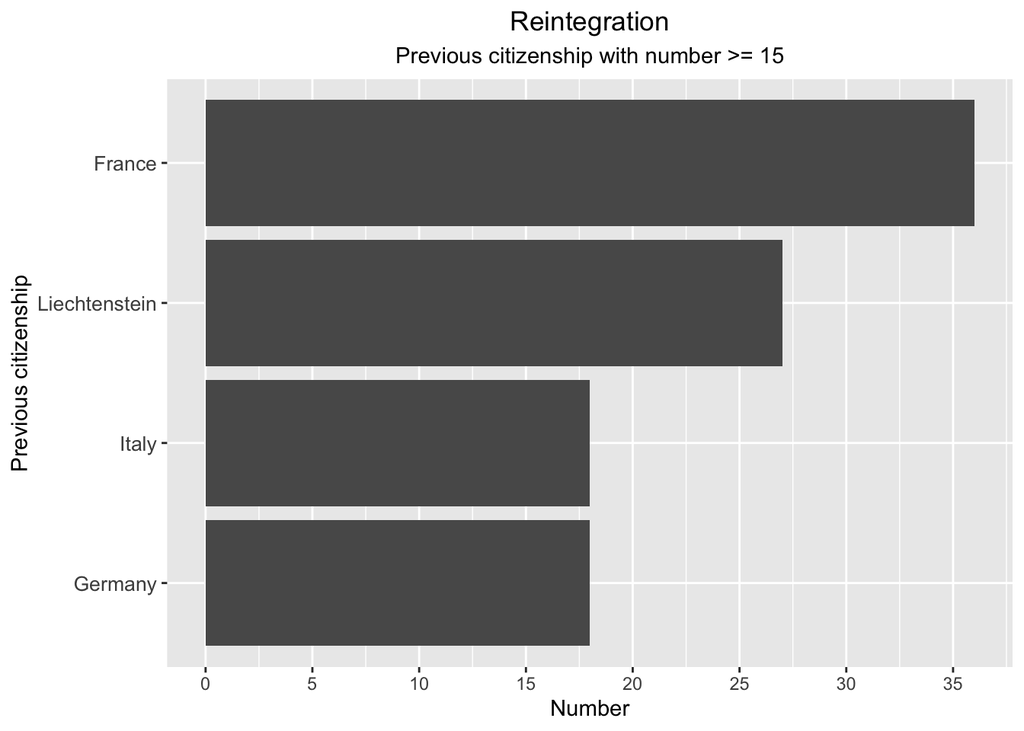

# Acquisition categorized by previous citizenship

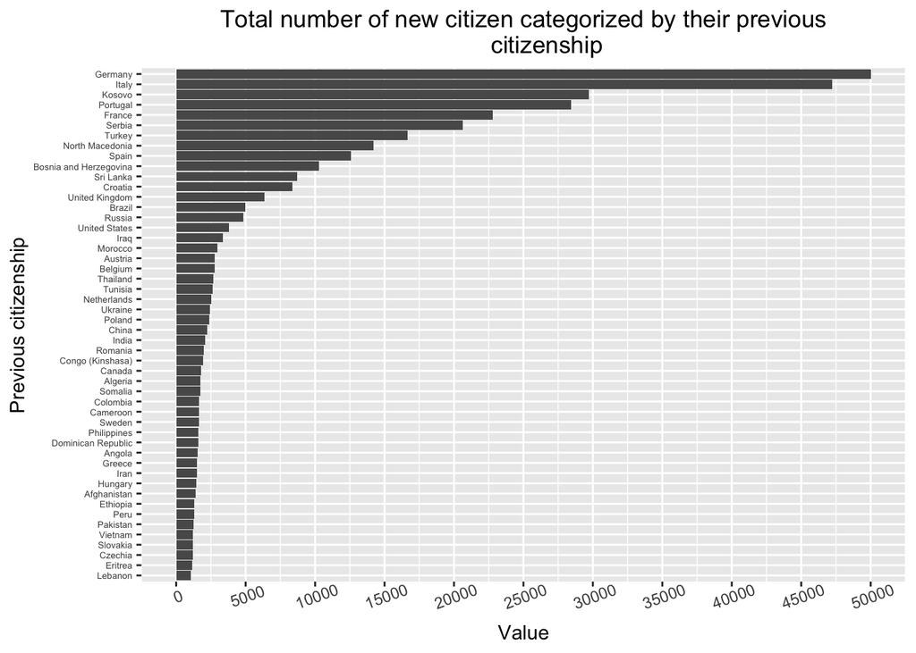

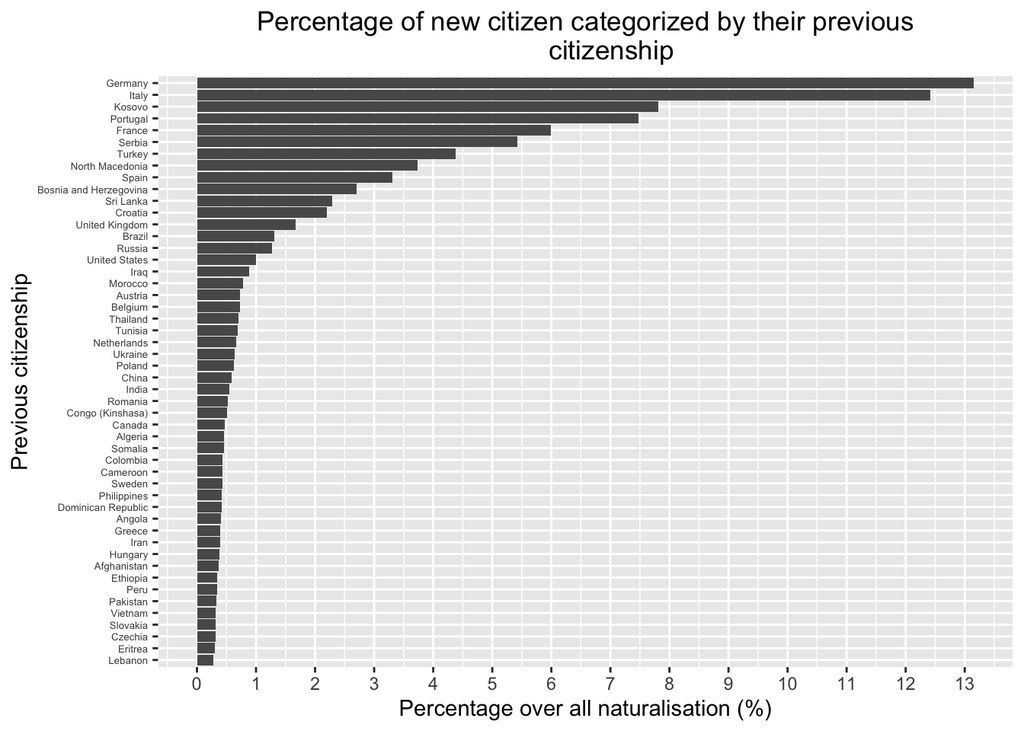

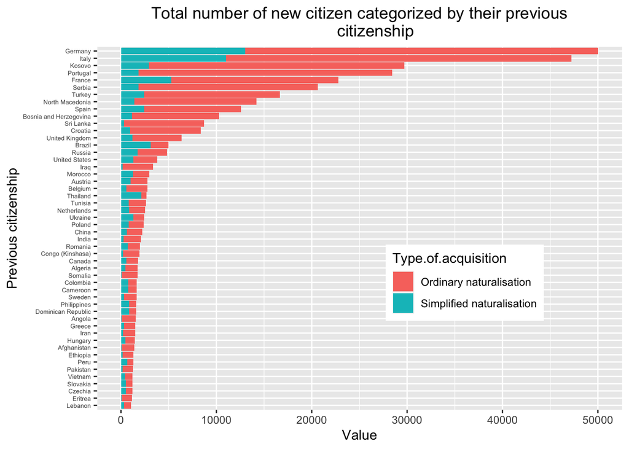